# ChainLadder: Claims reserving with R

Alessandro Carrato, Fabio Concina, Markus Gesmann, Dan Murphy, Mario Wüthrich and Wayne Zhang

2025-02-06

Abstract

The ChainLadder package provides various statistical methods which are typically used for the estimation of outstanding claims reserves in general insurance, including those to estimate the claims development results as required under Solvency II.

```
  Gesmann M, Murphy D, Zhang Y, Carrato A, Wuthrich M, Concina F, Dal
  Moro E (2025). _ChainLadder: Statistical Methods and Models for
  Claims Reserving in General Insurance_. R package version 0.2.20,
  <https://mages.github.io/ChainLadder/>.
```

## Introduction

### Claims reserving in insurance

The insurance industry, unlike other industries, does not sell products as such but promises. An insurance policy is a promise by the insurer to the policyholder to pay for future claims for an upfront received premium.

As a result insurers don’t know the upfront cost for their service, but rely on historical data analysis and judgement to predict a sustainable price for their offering. In General Insurance (or Non-Life Insurance, e.g. motor, property and casualty insurance) most policies run for a period of 12 months. However, the claims payment process can take years or even decades. Therefore often not even the delivery date of their product is known to insurers.

In particular losses arising from casualty insurance can take a long time to settle and even when the claims are acknowledged it may take time to establish the extent of the claims settlement cost. Claims can take years to materialize. A complex and costly example are the claims from asbestos liabilities, particularly those in connection with mesothelioma and lung damage arising from prolonged exposure to asbestos. A research report by a working party of the Institute and Faculty of Actuaries estimated that the un-discounted cost of UK mesothelioma-related claims to the UK Insurance Market for the period 2009 to 2050 could be around £10bn, see (Gravelsons et al. 2009). The cost for asbestos related claims in the US for the worldwide insurance industry was estimate to be around $120bn in 2002, see (Michaels 2002).

Thus, it should come as no surprise that the biggest item on the liability side of an insurer’s balance sheet is often the provision or reserves for future claims payments. Those reserves can be broken down in case reserves (or outstanding claims), which are losses already reported to the insurance company and losses that are incurred but not reported (IBNR) yet.

Historically, reserving was based on deterministic calculations with pen and paper, combined with expert judgement. Since the 1980’s, with the arrival of personal computer, spreadsheet software became very popular for reserving. Spreadsheets not only reduced the calculation time, but allowed actuaries to test different scenarios and the sensitivity of their forecasts.

As the computer became more powerful, ideas of more sophisticated models started to evolve. Changes in regulatory requirements, e.g. Solvency II in Europe, have fostered further research and promoted the use of stochastic and statistical techniques. In particular, for many countries extreme percentiles of reserve deterioration over a fixed time period have to be estimated for the purpose of capital setting.

Over the years several methods and models have been developed to estimate both the level and variability of reserves for insurance claims, see (Schmidt 2017) or (England and Verrall 2002) for an overview.

In practice the Mack chain-ladder and bootstrap chain-ladder models are used by many actuaries along with stress testing / scenario analysis and expert judgement to estimate ranges of reasonable outcomes, see the surveys of UK actuaries in 2002, (Lyons et al. 2002), and across the Lloyd’s market in 2012, (Orr 2012).

## The ChainLadder package

### Motivation

The ChainLadder package provides various statistical methods which are typically used for the estimation of outstanding claims reserves in general insurance. The package started out of presentations given by Markus Gesmann at the Stochastic Reserving Seminar at the Institute of Actuaries in 2007 and 2008, followed by talks at Casualty Actuarial Society (CAS) meetings joined by Dan Murphy in 2008 and Wayne Zhang in 2010.

Implementing reserving methods in R has several advantages. R provides:

- a rich language for statistical modelling and data manipulations allowing fast prototyping
- a very active user base, which publishes many extensions
- many interfaces to data bases and other applications, such as MS Excel
- an established framework for End User Computing, including documentation, testing and workflows with version control systems
- code written in plain text files, allowing effective knowledge transfer
- an effective way to collaborate over the internet
- built in functions to create reproducible research reports
- in combination with other tools such as LaTeX or RMarkdown easy to set up automated reporting facilities
- access to academic research, which is often first implemented in R

### Brief package overview

This vignette will give the reader a brief overview of the functionality of the ChainLadder package. The functions are discussed and explained in more detail in the respective help files and examples, see also (Gesmann 2014).

A set of demos is shipped with the packages and the list of demos is available via:

```r
demo(package="ChainLadder")
```

### Installation

You can install ChainLadder in the usual way from CRAN, e.g.:

```r
install.packages('ChainLadder')
```

For more details about installing packages see (R Development Core Team 2022b).

## Using the ChainLadder package

### Working with triangles

Historical insurance data is often presented in form of a triangle structure, showing the development of claims over time for each exposure (origin) period. An origin period could be the year the policy was written or earned, or the loss occurrence period. Of course the origin period doesn’t have to be yearly, e.g. quarterly or monthly origin periods are also often used. The development period of an origin period is also called age or lag.

Data on the diagonals present payments in the same calendar period. Note, data of individual policies is usually aggregated to homogeneous lines of business, division levels or perils.

Most reserving methods of the ChainLadder package expect triangles as input data sets with development periods along the columns and the origin period in rows. The package comes with several example triangles. The following R command will list them all:

```r
library(ChainLadder)
data(package="ChainLadder")
```

Let’s look at one example triangle more closely. The following triangle shows data from the Reinsurance Association of America (RAA):

```r
RAA
```

```
      dev
origin    1     2     3     4     5     6     7     8     9    10
  1981 5012  8269 10907 11805 13539 16181 18009 18608 18662 18834
  1982  106  4285  5396 10666 13782 15599 15496 16169 16704    NA
  1983 3410  8992 13873 16141 18735 22214 22863 23466    NA    NA
  1984 5655 11555 15766 21266 23425 26083 27067    NA    NA    NA
  1985 1092  9565 15836 22169 25955 26180    NA    NA    NA    NA
  1986 1513  6445 11702 12935 15852    NA    NA    NA    NA    NA
  1987  557  4020 10946 12314    NA    NA    NA    NA    NA    NA
  1988 1351  6947 13112    NA    NA    NA    NA    NA    NA    NA
  1989 3133  5395    NA    NA    NA    NA    NA    NA    NA    NA
  1990 2063    NA    NA    NA    NA    NA    NA    NA    NA    NA
```

This triangle shows the known values of loss from each origin year and of annual evaluations thereafter. For example, the known values of loss originating from the 1988 exposure period are 1351, 6947, and 13112 as of year ends 1988, 1989, and 1990, respectively. The *latest diagonal* – i.e., the vector 18834, 16704, $\dots$ 2063 from the upper right to the lower left – shows the most recent evaluation available. The column headings – 1, 2,$\dots$, 10 – hold the *ages* (in years) of the observations in the column relative to the beginning of the exposure period. For example, for the 1988 origin year, the age of the 13112 value, evaluated as of 1990-12-31, is three years.

The objective of a reserving exercise is to forecast the future claims development in the bottom right corner of the triangle and potential further developments beyond development age 10. Eventually all claims for a given origin period will be settled, but it is not always obvious to judge how many years or even decades it will take. We speak of long and short tail business depending on the time it takes to pay all claims.

#### Plotting triangles

The first thing you often want to do is to plot the data to get an overview. For a data set of class `triangle` the ChainLadder package provides default plotting methods to give a graphical overview of the data:

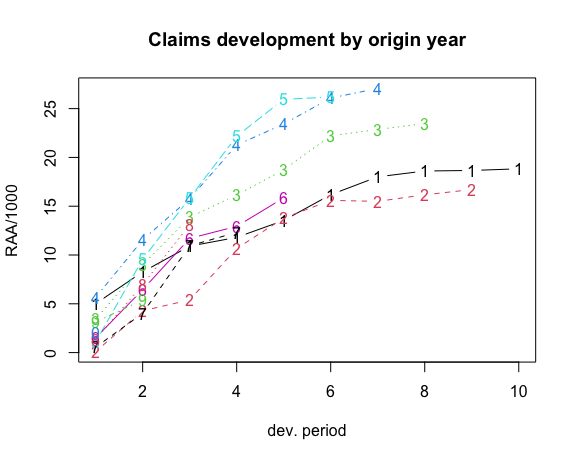

Claims development chart of the RAA triangle, with one line per origin period.

```r
plot(RAA/1000,  main = "Claims development by origin year")
```

Setting the argument `lattice=TRUE` will produce individual plots for each origin period.

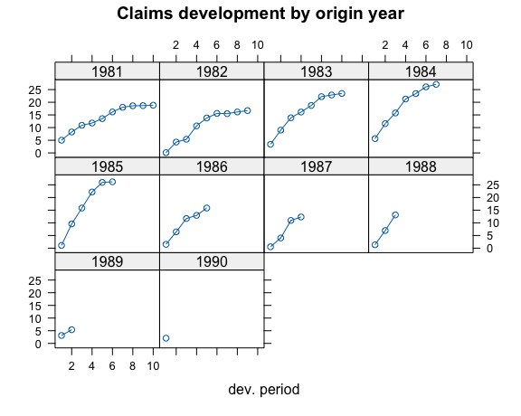

Claims development chart of the RAA triangle, with individual panels for each origin period

```r
plot(RAA/1000, lattice=TRUE, main = "Claims development by origin year")
```

You will notice from the plots that the triangle `RAA` presents claims developments for the origin years 1981 to 1990 in a cumulative form. For more information on the triangle plotting functions see the help pages of `plot.triangle`.

### Transforming triangles between cumulative and incremental representation

The ChainLadder packages comes with two helper functions, `cum2incr` and `incr2cum` to transform cumulative triangles into incremental triangles and vice versa:

```r
raa.inc <- cum2incr(RAA)
## Show first origin period and its incremental development
raa.inc[1,]
```

```
   1    2    3    4    5    6    7    8    9   10
5012 3257 2638  898 1734 2642 1828  599   54  172
```

```r
raa.cum <- incr2cum(raa.inc)
## Show first origin period and its cumulative development
raa.cum[1,]
```

```
    1     2     3     4     5     6     7     8     9    10
 5012  8269 10907 11805 13539 16181 18009 18608 18662 18834
```

#### Importing triangles from external data sources

In most cases you want to analyse your own data, usually stored in data bases or spreadsheets.

##### Importing a triangle from a spreadsheet

There are many ways to import the data from a spreadsheet. A quick and dirty solution is using a CSV-file.

Open a new workbook and copy your triangle into cell A1, with the first column being the accident or origin period and the first row describing the development period or age.

Ensure the triangle has no formatting, such a commas to separate thousands, as those cells will be saved as characters.

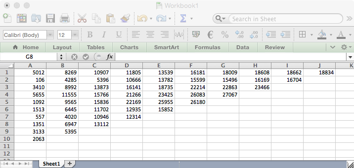

Screen shot of a triangle in a spreadsheet software.

Now open R and go through the following commands:

```r
myCSVfile <- "path/to/folder/with/triangle.csv"
## Use the R command:
# myCSVfile <- file.choose() to select the file interactively
tri <- read.csv(file=myCSVfile, header = FALSE)
## Use read.csv2 if semicolons are used as a separator likely
## to be the case if you are in continental Europe
library(ChainLadder)
## Convert to triangle
tri <- as.triangle(as.matrix(tri))
# Job done.
```

Small data sets can be transferred to R backwards and forwards via the clipboard under MS Windows.

Select a data set in the spreadsheet and copy it into the clipboard, then go to R and type:

```r
tri <- read.table(file="clipboard", sep="\t", na.strings="")
```

##### Reading data from a data base

R makes it easy to access data using SQL statements, e.g. via an ODBC connection[^1], for more details see (R Development Core Team 2022a).

In this section we use data stored in a CSV-file[^2] to demonstrate some typical operations you will want to carry out with data stored in data bases. CSV stands for comma separated values, stored in a text file. Note many European countries use a comma as decimal point and a semicolon as field separator, see also the help file to `read.csv2`. In most cases your triangles will be stored in tables and not in a classical triangle shape. The ChainLadder package contains a CSV-file with sample data in a long table format. We read the data into R’s memory with the `read.csv` command and look at the first couple of rows and summarise it:

```r
filename <-  file.path(system.file("Database",
                                   package="ChainLadder"),
                       "TestData.csv")
myData <- read.csv(filename)
head(myData)
```

```
  origin dev  value lob
1   1977   1 153638 ABC
2   1978   1 178536 ABC
3   1979   1 210172 ABC
4   1980   1 211448 ABC
5   1981   1 219810 ABC
6   1982   1 205654 ABC
```

```r
summary(myData)
```

```
     origin          dev            value             lob
 Min.   :   1   Min.   : 1.00   Min.   : -17657   Length:701
 1st Qu.:   3   1st Qu.: 2.00   1st Qu.:  10324   Class :character
 Median :   6   Median : 4.00   Median :  72468   Mode  :character
 Mean   : 642   Mean   : 4.61   Mean   : 176632
 3rd Qu.:1979   3rd Qu.: 7.00   3rd Qu.: 197716
 Max.   :1991   Max.   :14.00   Max.   :3258646
```

Let’s focus on one subset of the data. We select the RAA data again:

```r
raa <- subset(myData, lob %in% "RAA")
head(raa)
```

```
   origin dev value lob
67   1981   1  5012 RAA
68   1982   1   106 RAA
69   1983   1  3410 RAA
70   1984   1  5655 RAA
71   1985   1  1092 RAA
72   1986   1  1513 RAA
```

To transform the long table of the RAA data into a triangle we use the function `as.triangle`. The arguments we have to specify are the column names of the origin and development period and further the column which contains the values:

```r
raa.tri <- as.triangle(raa,
                       origin="origin",
                       dev="dev",
                       value="value")
raa.tri
```

```
      dev
origin    1    2    3    4    5    6    7   8   9  10
  1981 5012 3257 2638  898 1734 2642 1828 599  54 172
  1982  106 4179 1111 5270 3116 1817 -103 673 535  NA
  1983 3410 5582 4881 2268 2594 3479  649 603  NA  NA
  1984 5655 5900 4211 5500 2159 2658  984  NA  NA  NA
  1985 1092 8473 6271 6333 3786  225   NA  NA  NA  NA
  1986 1513 4932 5257 1233 2917   NA   NA  NA  NA  NA
  1987  557 3463 6926 1368   NA   NA   NA  NA  NA  NA
  1988 1351 5596 6165   NA   NA   NA   NA  NA  NA  NA
  1989 3133 2262   NA   NA   NA   NA   NA  NA  NA  NA
  1990 2063   NA   NA   NA   NA   NA   NA  NA  NA  NA
```

We note that the data has been stored as an incremental data set. As mentioned above, we could now use the function `incr2cum` to transform the triangle into a cumulative format.

We can transform a triangle back into a data frame structure:

```r
raa.df <- as.data.frame(raa.tri, na.rm=TRUE)
head(raa.df)
```

```
       origin dev value
1981-1   1981   1  5012
1982-1   1982   1   106
1983-1   1983   1  3410
1984-1   1984   1  5655
1985-1   1985   1  1092
1986-1   1986   1  1513
```

This is particularly helpful when you would like to store your results back into a data base. The following figure gives you an idea of a potential data flow between R and data bases.

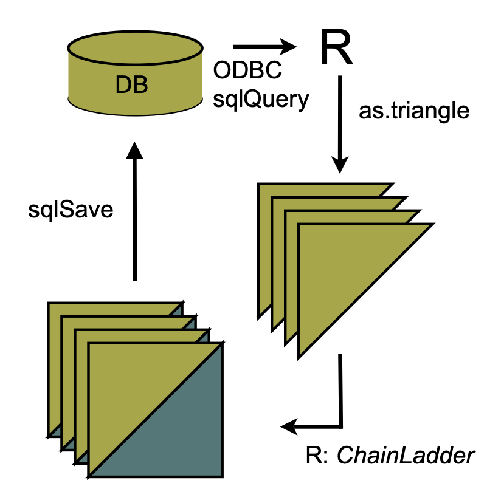

Flow chart of data between R and data bases

#### Creating triangles interactively

For small data sets or while testing procedures, it may be useful to create triangles interactively from the command line. There are two main ways to proceed. With the first we create a matrix of data (including missing values in the lower right portion of the triangle) and then convert it into a triangle with `as.triangle`:

```r
as.triangle(matrix(c(100, 150, 175, 180, 200,
                     110, 168, 192, 205, NA,
                     115, 169, 202, NA,  NA,
                     125, 185, NA,  NA,  NA,
                     150, NA,  NA,  NA,  NA),
                   nrow = 5, byrow = TRUE))
```

```
      dev
origin   1   2   3   4   5
     1 100 150 175 180 200
     2 110 168 192 205  NA
     3 115 169 202  NA  NA
     4 125 185  NA  NA  NA
     5 150  NA  NA  NA  NA
```

We may also create the triangle directly with `triangle` by providing the rows (or columns) of *known* data as vectors, thereby omitting the missing values:

```r
triangle(c(100, 150, 175, 180, 200),
         c(110, 168, 192, 205),
         c(115, 169, 202),
         c(125, 185),
         150)
```

```
      dev
origin   1   2   3   4   5
     1 100 150 175 180 200
     2 110 168 192 205  NA
     3 115 169 202  NA  NA
     4 125 185  NA  NA  NA
     5 150  NA  NA  NA  NA
```

## Chain-ladder methods

The classical chain-ladder is a deterministic algorithm to forecast claims based on historical data. It assumes that the proportional developments of claims from one development period to the next are the same for all origin years.

### Basic idea

Most commonly as a first step, the age-to-age link ratios are calculated as the volume weighted average development ratios of a cumulative loss development triangle from one development period to the next $C_{ik}, i,k =1, \dots, n$.

$$\begin{aligned}
f_{k} &= \frac{\sum_{i=1}^{n-k}
C_{i,k+1}}{\sum_{i=1}^{n-k}C_{i,k}}
\end{aligned}$$

```r
# Calculate age-to-age factors for RAA triangle
n <- 10
f <- sapply(1:(n-1),
            function(i){
              sum(RAA[c(1:(n-i)),i+1])/sum(RAA[c(1:(n-i)),i])
            }
)
f
```

```
[1] 2.999 1.624 1.271 1.172 1.113 1.042 1.033 1.017 1.009
```

Often it is not suitable to assume that the oldest origin year is fully developed. A typical approach is to extrapolate the development ratios, e.g. assuming a linear model on a log scale.

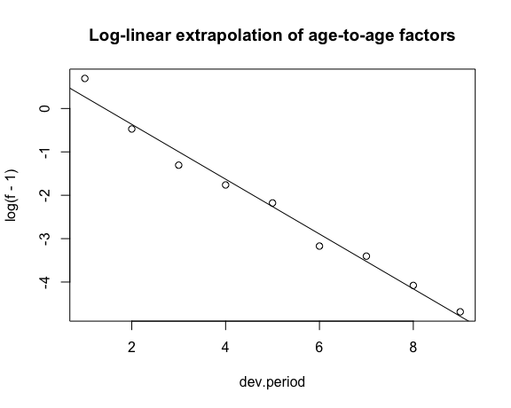

```r
dev.period <- 1:(n-1)
plot(log(f-1) ~ dev.period,
     main="Log-linear extrapolation of age-to-age factors")
tail.model <- lm(log(f-1) ~ dev.period)
abline(tail.model)
```

```r
co <- coef(tail.model)
## extrapolate another 100 dev. period
tail <- exp(co[1] + c(n:(n + 100)) * co[2]) + 1
f.tail <- prod(tail)
f.tail
```

```
[1] 1.009
```

The age-to-age factors allow us to plot the expected claims development patterns.

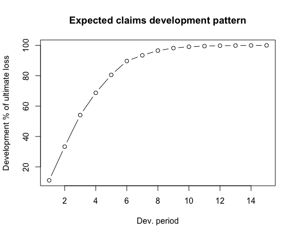

```r
plot(100*(rev(1/cumprod(rev(c(f, tail[tail>1.0001]))))), t="b",
     main="Expected claims development pattern",
     xlab="Dev. period", ylab="Development % of ultimate loss")
```

The link ratios are then applied to the latest known cumulative claims amount to forecast the next development period. The *squaring* of the RAA triangle is calculated below, where an *ultimate* column is appended to the right to accommodate the expected development beyond the oldest age (10) of the triangle due to the tail factor (1.009) being greater than unity.

```r
f <- c(f, f.tail)
fullRAA <- cbind(RAA, Ult = rep(0, 10))
for(k in 1:n){
  fullRAA[(n-k+1):n, k+1] <- fullRAA[(n-k+1):n,k]*f[k]
}
round(fullRAA)
```

```
        1     2     3     4     5     6     7     8     9    10   Ult
1981 5012  8269 10907 11805 13539 16181 18009 18608 18662 18834 19012
1982  106  4285  5396 10666 13782 15599 15496 16169 16704 16858 17017
1983 3410  8992 13873 16141 18735 22214 22863 23466 23863 24083 24311
1984 5655 11555 15766 21266 23425 26083 27067 27967 28441 28703 28974
1985 1092  9565 15836 22169 25955 26180 27278 28185 28663 28927 29200
1986 1513  6445 11702 12935 15852 17649 18389 19001 19323 19501 19685
1987  557  4020 10946 12314 14428 16064 16738 17294 17587 17749 17917
1988 1351  6947 13112 16664 19525 21738 22650 23403 23800 24019 24246
1989 3133  5395  8759 11132 13043 14521 15130 15634 15898 16045 16196
1990 2063  6188 10046 12767 14959 16655 17353 17931 18234 18402 18576
```

The total estimated outstanding loss under this method is about 54100:

```r
sum(fullRAA[ ,11] - getLatestCumulative(RAA))
```

```
[1] 54146
```

This approach is also called Loss Development Factor (LDF) method.

More generally, the factors used to square the triangle need not always be drawn from the dollar weighted averages of the triangle. Other sources of factors from which the actuary may *select* link ratios include simple averages from the triangle, averages weighted toward more recent observations or adjusted for outliers, and benchmark patterns based on related, more credible loss experience. Also, since the ultimate value of claims is simply the product of the most current diagonal and the cumulative product of the link ratios, the completion of interior of the triangle is usually not displayed in favor of that multiplicative calculation.

For example, suppose the actuary decides that the volume weighted factors from the RAA triangle are representative of expected future growth, but discards the 1.009 tail factor derived from the loglinear fit in favor of a five percent tail (1.05) based on loss data from a larger book of similar business. The LDF method might be displayed in R as follows.

```r
linkratios <- c(attr(ata(RAA), "vwtd"), tail = 1.05)
round(linkratios, 3) # display to only three decimal places
```

```
  1-2   2-3   3-4   4-5   5-6   6-7   7-8   8-9  9-10  tail
2.999 1.624 1.271 1.172 1.113 1.042 1.033 1.017 1.009 1.050
```

```r
LDF <- rev(cumprod(rev(linkratios)))
names(LDF) <- colnames(RAA) # so the display matches the triangle
round(LDF, 3)
```

```
    1     2     3     4     5     6     7     8     9    10
9.366 3.123 1.923 1.513 1.292 1.160 1.113 1.078 1.060 1.050
```

```r
currentEval <- getLatestCumulative(RAA)
# Reverse the LDFs so the first, least mature factor [1]
#   is applied to the last origin year (1990)
EstdUlt <- currentEval * rev(LDF) #
# Start with the body of the exhibit
Exhibit <- data.frame(currentEval, LDF = round(rev(LDF), 3), EstdUlt)
# Tack on a Total row
Exhibit <- rbind(Exhibit,
data.frame(currentEval=sum(currentEval), LDF=NA, EstdUlt=sum(EstdUlt),
           row.names = "Total"))
Exhibit
```

```
      currentEval   LDF EstdUlt
1981        18834 1.050   19776
1982        16704 1.060   17701
1983        23466 1.078   25288
1984        27067 1.113   30138
1985        26180 1.160   30373
1986        15852 1.292   20476
1987        12314 1.513   18637
1988        13112 1.923   25220
1989         5395 3.123   16847
1990         2063 9.366   19323
Total      160987    NA  223778
```

Since the early 1990s several papers have been published to embed the simple chain-ladder method into a statistical framework. Ben Zehnwirth and Glenn Barnett point out in (Zehnwirth and Barnett 2000) that the age-to-age link ratios can be regarded as the coefficients of a weighted linear regression through the origin, see also (Murphy 1994).

```r
lmCL <- function(i, Triangle){
  lm(y~x+0, weights=1/Triangle[,i],
     data=data.frame(x=Triangle[,i], y=Triangle[,i+1]))
}
sapply(lapply(c(1:(n-1)), lmCL, RAA), coef)
```

```
    x     x     x     x     x     x     x     x     x
2.999 1.624 1.271 1.172 1.113 1.042 1.033 1.017 1.009
```

### Mack chain-ladder

Thomas Mack published in 1993 (Mack 1993) a method which estimates the standard errors of the chain-ladder forecast without assuming a distribution under three conditions.

Following the notation of Mack (Mack 1999) let $C_{ik}$ denote the cumulative loss amounts of origin period (e.g. accident year) $i=1,\ldots,m$, with losses known for development period (e.g. development year) $k \le n+1-i$.

In order to forecast the amounts $C_{ik}$ for $k > n+1-i$ the Mack chain-ladder-model assumes:

$$\begin{aligned}
\mbox{CL1: } & E[ F_{ik}| C_{i1},C_{i2},\ldots,C_{ik} ] = f_k
\mbox{ with } F_{ik}=\frac{C_{i,k+1}}{C_{ik}}\\
\mbox{CL2: } & Var( \frac{C_{i,k+1}}{C_{ik}} | C_{i1},C_{i2},
\ldots,C_{ik} ) = \frac{\sigma_k^2}{w_{ik} C^\alpha_{ik}}\\
\mbox{CL3: } & \{C_{i1},\ldots,C_{in}\}, \{
C_{j1},\ldots,C_{jn}\},\mbox{ are independent for origin period } i
\neq j
\end{aligned}$$

with $w_{ik} \in [0;1], \alpha \in \{0,1,2\}$. If these assumptions hold, the Mack chain-ladder-model gives an unbiased estimator for IBNR (Incurred But Not Reported) claims.

The Mack chain-ladder model can be regarded as a weighted linear regression through the origin for each development period: `lm(y ~ x + 0, weights=w/x^(2-alpha))`, where $y$ is the vector of claims at development period $k+1$ and $x$ is the vector of claims at development period $k$.

The Mack method is implemented in the ChainLadder package via the function `MackChainLadder`.

As an example we apply the `MackChainLadder` function to our triangle `RAA`:

```r
mack <- MackChainLadder(RAA, est.sigma="Mack")
mack # same as summary(mack)
```

```
MackChainLadder(Triangle = RAA, est.sigma = "Mack")

     Latest Dev.To.Date Ultimate   IBNR Mack.S.E CV(IBNR)
1981 18,834       1.000   18,834      0        0      NaN
1982 16,704       0.991   16,858    154      206    1.339
1983 23,466       0.974   24,083    617      623    1.010
1984 27,067       0.943   28,703  1,636      747    0.457
1985 26,180       0.905   28,927  2,747    1,469    0.535
1986 15,852       0.813   19,501  3,649    2,002    0.549
1987 12,314       0.694   17,749  5,435    2,209    0.406
1988 13,112       0.546   24,019 10,907    5,358    0.491
1989  5,395       0.336   16,045 10,650    6,333    0.595
1990  2,063       0.112   18,402 16,339   24,566    1.503

              Totals
Latest:   160,987.00
Dev:            0.76
Ultimate: 213,122.23
IBNR:      52,135.23
Mack.S.E   26,909.01
CV(IBNR):       0.52
```

We can access the loss development factors and the full triangle via:

```r
mack$f
```

```
 [1] 2.999 1.624 1.271 1.172 1.113 1.042 1.033 1.017 1.009 1.000
```

```r
mack$FullTriangle
```

```
      dev
origin    1     2     3     4     5     6     7     8     9    10
  1981 5012  8269 10907 11805 13539 16181 18009 18608 18662 18834
  1982  106  4285  5396 10666 13782 15599 15496 16169 16704 16858
  1983 3410  8992 13873 16141 18735 22214 22863 23466 23863 24083
  1984 5655 11555 15766 21266 23425 26083 27067 27967 28441 28703
  1985 1092  9565 15836 22169 25955 26180 27278 28185 28663 28927
  1986 1513  6445 11702 12935 15852 17649 18389 19001 19323 19501
  1987  557  4020 10946 12314 14428 16064 16738 17294 17587 17749
  1988 1351  6947 13112 16664 19525 21738 22650 23403 23800 24019
  1989 3133  5395  8759 11132 13043 14521 15130 15634 15898 16045
  1990 2063  6188 10046 12767 14959 16655 17353 17931 18234 18402
```

If you are only interested in the summary statistics then use:

```r
mack_smmry <- summary(mack) # See also ?summary.MackChainLadder
mack_smmry$ByOrigin
```

```
     Latest Dev.To.Date Ultimate    IBNR Mack.S.E CV(IBNR)
1981  18834      1.0000    18834     0.0      0.0      NaN
1982  16704      0.9909    16858   154.0    206.2   1.3395
1983  23466      0.9744    24083   617.4    623.4   1.0097
1984  27067      0.9430    28703  1636.1    747.2   0.4567
1985  26180      0.9050    28927  2746.7   1469.5   0.5350
1986  15852      0.8129    19501  3649.1   2001.9   0.5486
1987  12314      0.6938    17749  5435.3   2209.2   0.4065
1988  13112      0.5459    24019 10907.2   5357.9   0.4912
1989   5395      0.3362    16045 10650.0   6333.2   0.5947
1990   2063      0.1121    18402 16339.4  24566.3   1.5035
```

```r
mack_smmry$Totals
```

```
              Totals
Latest:    1.610e+05
Dev:       7.554e-01
Ultimate:  2.131e+05
IBNR:      5.214e+04
Mack S.E.: 2.691e+04
CV(IBNR):  5.161e-01
```

To check that Mack’s assumption are valid review the residual plots, you should see no trends in either of them.

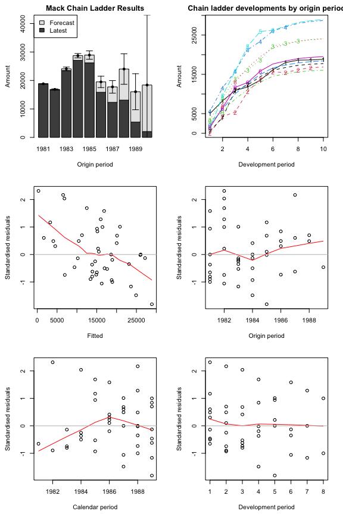

Some residual show clear trends, indicating that the Mack assumptions are not well met

```r
plot(mack)
```

We can plot the development, including the forecast and estimated standard errors by origin period by setting the argument `lattice=TRUE`.

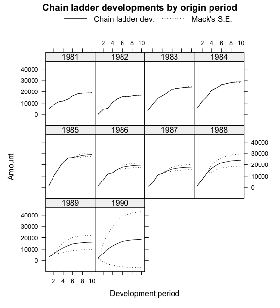

```r
plot(mack, lattice=TRUE)
```

#### Using a subset of the triangle

The `weights` argument allows for the selection of a subset of the triangle for the projections.

For example, in order to use only the last 5 calendar years of the triangle, set the `weights` as follows:

```r
calPeriods <- (row(RAA) + col(RAA) - 1)
(weights <- ifelse(calPeriods <= 5, 0, ifelse(calPeriods > 10, NA, 1)))
```

```
      [,1] [,2] [,3] [,4] [,5] [,6] [,7] [,8] [,9] [,10]
 [1,]    0    0    0    0    0    1    1    1    1     1
 [2,]    0    0    0    0    1    1    1    1    1    NA
 [3,]    0    0    0    1    1    1    1    1   NA    NA
 [4,]    0    0    1    1    1    1    1   NA   NA    NA
 [5,]    0    1    1    1    1    1   NA   NA   NA    NA
 [6,]    1    1    1    1    1   NA   NA   NA   NA    NA
 [7,]    1    1    1    1   NA   NA   NA   NA   NA    NA
 [8,]    1    1    1   NA   NA   NA   NA   NA   NA    NA
 [9,]    1    1   NA   NA   NA   NA   NA   NA   NA    NA
[10,]    1   NA   NA   NA   NA   NA   NA   NA   NA    NA
```

```r
MackChainLadder(RAA, weights=weights, est.sigma = "Mack")
```

```
MackChainLadder(Triangle = RAA, weights = weights, est.sigma = "Mack")

     Latest Dev.To.Date Ultimate   IBNR Mack.S.E CV(IBNR)
1981 18,834      1.0000   18,834      0        0      NaN
1982 16,704      0.9909   16,858    154      206    1.339
1983 23,466      0.9744   24,083    617      623    1.010
1984 27,067      0.9430   28,703  1,636      747    0.457
1985 26,180      0.9050   28,927  2,747    1,469    0.535
1986 15,852      0.8229   19,264  3,412    2,039    0.598
1987 12,314      0.7106   17,329  5,015    2,144    0.428
1988 13,112      0.5613   23,361 10,249    4,043    0.395
1989  5,395      0.2935   18,384 12,989    5,931    0.457
1990  2,063      0.0843   24,463 22,400   16,779    0.749

              Totals
Latest:   160,987.00
Dev:            0.73
Ultimate: 220,207.63
IBNR:      59,220.63
Mack.S.E   19,859.00
CV(IBNR):       0.34
```

### Munich chain-ladder

Munich chain-ladder is a reserving method that reduces the gap between IBNR projections based on paid losses and IBNR projections based on incurred losses. The Munich chain-ladder method uses correlations between paid and incurred losses of the historical data into the projection for the future (Quarg and Mack 2004).

```r
MCLpaid
```

```
      dev
origin    1    2    3    4    5    6    7
     1  576 1804 1970 2024 2074 2102 2131
     2  866 1948 2162 2232 2284 2348   NA
     3 1412 3758 4252 4416 4494   NA   NA
     4 2286 5292 5724 5850   NA   NA   NA
     5 1868 3778 4648   NA   NA   NA   NA
     6 1442 4010   NA   NA   NA   NA   NA
     7 2044   NA   NA   NA   NA   NA   NA
```

```r
MCLincurred
```

```
      dev
origin    1    2    3    4    5    6    7
     1  978 2104 2134 2144 2174 2182 2174
     2 1844 2552 2466 2480 2508 2454   NA
     3 2904 4354 4698 4600 4644   NA   NA
     4 3502 5958 6070 6142   NA   NA   NA
     5 2812 4882 4852   NA   NA   NA   NA
     6 2642 4406   NA   NA   NA   NA   NA
     7 5022   NA   NA   NA   NA   NA   NA
```

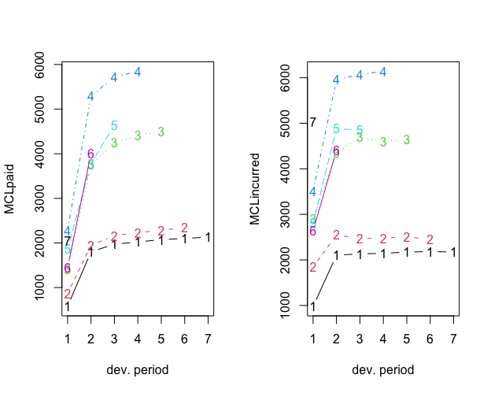

```r
par(mfrow=c(1,2))
plot(MCLpaid)
plot(MCLincurred)
```

```r
par(mfrow=c(1,1))
```

```r
# Following the example in Quarg's (2004) paper:
MCL <- MunichChainLadder(MCLpaid, MCLincurred, est.sigmaP=0.1, est.sigmaI=0.1)
MCL
```

```
MunichChainLadder(Paid = MCLpaid, Incurred = MCLincurred, est.sigmaP = 0.1,
    est.sigmaI = 0.1)

  Latest Paid Latest Incurred Latest P/I Ratio Ult. Paid Ult. Incurred
1       2,131           2,174            0.980     2,131         2,174
2       2,348           2,454            0.957     2,383         2,444
3       4,494           4,644            0.968     4,597         4,629
4       5,850           6,142            0.952     6,119         6,176
5       4,648           4,852            0.958     4,937         4,950
6       4,010           4,406            0.910     4,656         4,665
7       2,044           5,022            0.407     7,549         7,650
  Ult. P/I Ratio
1          0.980
2          0.975
3          0.993
4          0.991
5          0.997
6          0.998
7          0.987

Totals
            Paid Incurred P/I Ratio
Latest:   25,525   29,694      0.86
Ultimate: 32,371   32,688      0.99
```

You can use `summary(MCL)$ByOrigin` and `summary(MCL)$Totals` to extract the information from the output above.

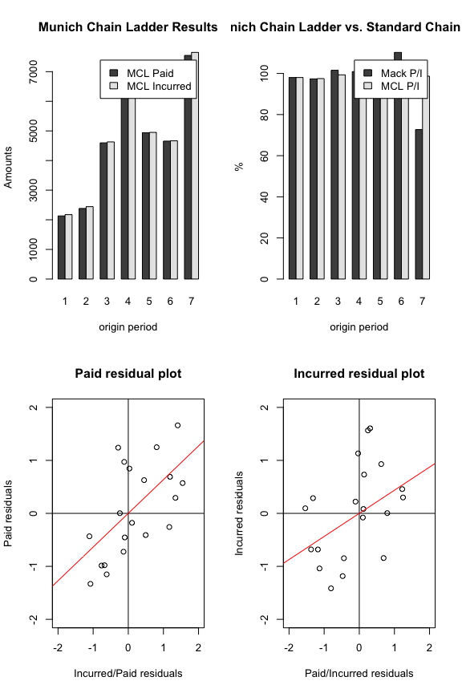

```r
plot(MCL)
```

### Bootstrap chain-ladder

The `BootChainLadder` function uses a two-stage bootstrapping/simulation approach following the paper by England and Verrall (England and Verrall 2002). In the first stage an ordinary chain-ladder methods is applied to the cumulative claims triangle. From this we calculate the scaled Pearson residuals which we bootstrap R times to forecast future incremental claims payments via the standard chain-ladder method. In the second stage we simulate the process error with the bootstrap value as the mean and using the process distribution assumed. The set of reserves obtained in this way forms the predictive distribution, from which summary statistics such as mean, prediction error or quantiles can be derived.

```r
## See also the example in section 8 of England & Verrall (2002)
## on page 55.
B <- BootChainLadder(RAA, R=999, process.distr="gamma")
B
```

```
BootChainLadder(Triangle = RAA, R = 999, process.distr = "gamma")

     Latest Mean Ultimate Mean IBNR IBNR.S.E IBNR 75% IBNR 95%
1981 18,834        18,834         0        0        0        0
1982 16,704        16,886       182      761      171    1,499
1983 23,466        24,151       685    1,308    1,159    3,151
1984 27,067        28,860     1,793    1,938    2,743    5,790
1985 26,180        29,148     2,968    2,457    4,177    7,267
1986 15,852        19,660     3,808    2,558    5,153    8,763
1987 12,314        18,127     5,813    3,204    7,621   11,890
1988 13,112        24,459    11,347    5,135   14,629   20,541
1989  5,395        16,474    11,079    6,228   14,615   22,680
1990  2,063        19,400    17,337   14,491   24,601   44,238

                 Totals
Latest:         160,987
Mean Ultimate:  215,998
Mean IBNR:       55,011
IBNR.S.E         19,839
Total IBNR 75%:  66,489
Total IBNR 95%:  92,253
```

You can use `summary(B)$ByOrigin` and `summary(B)$Totals` to extract the information from the output above.

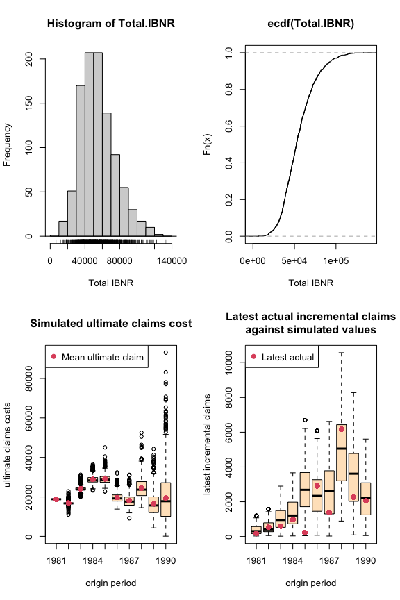

```r
plot(B)
```

Quantiles of the bootstrap IBNR can be calculated via the `quantile` function:

```r
quantile(B, c(0.75,0.95,0.99, 0.995))
```

```
$ByOrigin
     IBNR 75% IBNR 95% IBNR 99% IBNR 99.5%
1981      0.0        0        0          0
1982    171.3     1499     3062       3475
1983   1159.5     3151     5192       5992
1984   2743.2     5790     8057       8321
1985   4176.8     7267    10989      11947
1986   5153.2     8763    11795      12514
1987   7620.7    11890    15136      15964
1988  14628.6    20541    25631      31739
1989  14614.6    22680    29831      32598
1990  24601.3    44238    60771      67705

$Totals
            Totals
IBNR 75%:    66489
IBNR 95%:    92253
IBNR 99%:   112310
IBNR 99.5%: 116671
```

The distribution of the IBNR appears to follow a log-normal distribution, so let’s fit it:

```r
## fit a distribution to the IBNR
library(MASS)
plot(ecdf(B$IBNR.Totals))
## fit a log-normal distribution
fit <- fitdistr(B$IBNR.Totals[B$IBNR.Totals>0], "lognormal")
fit
```

```
    meanlog      sdlog
  10.848323    0.376221
 ( 0.011903) ( 0.008417)
```

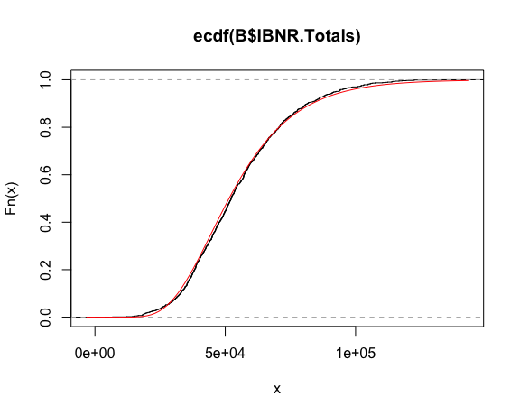

```r
curve(plnorm(x,fit$estimate["meanlog"], fit$estimate["sdlog"]),
      col="red", add=TRUE)
```

### Multivariate chain-ladder

The Mack chain-ladder technique can be generalized to the multivariate setting where multiple reserving triangles are modelled and developed simultaneously. The advantage of the multivariate modelling is that correlations among different triangles can be modelled, which will lead to more accurate uncertainty assessments. Reserving methods that explicitly model the between-triangle contemporaneous correlations can be found in (Pröhl and Schmidt 2005), (Michael Merz and Wüthrich 2008b). Another benefit of multivariate loss reserving is that structural relationships between triangles can also be reflected, where the development of one triangle depends on past losses from other triangles. For example, there is generally need for the joint development of the paid and incurred losses (Quarg and Mack 2004). Most of the chain-ladder-based multivariate reserving models can be summarised as sequential seemingly unrelated regressions (Zhang 2010). We note another strand of multivariate loss reserving builds a hierarchical structure into the model to allow estimation of one triangle to “borrow strength” from other triangles, reflecting the core insight of actuarial credibility (Zhang, Dukic, and Guszcza 2012).

Denote $Y_{i,k}=(Y^{(1)}_{i,k}, \cdots ,Y^{(N)}_{i,k})$ as an $N \times 1$ vector of cumulative losses at accident year $i$ and development year $k$ where $(n)$ refers to the n-th triangle. (Zhang 2010) specifies the model in development period $k$ as:

$$\begin{equation}
Y_{i,k+1} = A_k + B_k \cdot Y_{i,k} + \epsilon_{i,k},
\end{equation}$$

where $A_k$ is a column of intercepts and $B_k$ is the development matrix for development period $k$. Assumptions for this model are:

$$\begin{aligned}
&E(\epsilon_{i,k}|Y_{i,1}, \cdots,Y_{i,I+1-k}) =0, \\
&cov(\epsilon_{i,k}|Y_{i,1}, \cdots,
Y_{i,I+1-k})=D(Y_{i,k}^{-\delta/2}) \, \Sigma_k \,
D(Y_{i,k}^{-\delta/2}), \\
&\text{losses of different accident years are independent}, \\
&\epsilon_{i,k} \text{ are symmetrically distributed}.
\end{aligned}$$

In the above, $D$ is the diagonal operator, and $\delta$ is a known positive value that controls how the variance depends on the mean (as weights). This model is referred to as the general multivariate chain ladder [GMCL] in (Zhang 2010). A important special case where $A_k=0$ and $B_k$’s are diagonal is a naive generalization of the chain-ladder, often referred to as the multivariate chain-ladder [MCL] (Pröhl and Schmidt 2005).

In the following, we first introduce the class `triangles`, for which we have defined several utility functions. Indeed, any input triangles to the `MultiChainLadder` function will be converted to `triangles` internally. We then present loss reserving methods based on the MCL and GMCL models in turn.

Consider the two liability loss triangles from (Michael Merz and Wüthrich 2008b). It comes as a list of two matrices:

```r
str(liab)
```

```
List of 2
 $ GeneralLiab: num [1:14, 1:14] 59966 49685 51914 84937 98921 ...
 $ AutoLiab   : num [1:14, 1:14] 114423 152296 144325 145904 170333 ...
```

We can convert a list to a `triangles` object using

```r
liab2 <- as(liab, "triangles")
class(liab2)
```

```
[1] "triangles"
attr(,"package")
[1] "ChainLadder"
```

We can find out what methods are available for this class:

```r
showMethods(classes = "triangles")
```

For example, if we want to extract the last three columns of each triangle, we can use the `[` operator as follows:

```r
# use drop = TRUE to remove rows that are all NA's
liab2[, 12:14, drop = TRUE]
```

```
An object of class "triangles"
[[1]]
       [,1]   [,2]   [,3]
[1,] 540873 547696 549589
[2,] 563571 562795     NA
[3,] 602710     NA     NA

[[2]]
       [,1]   [,2]   [,3]
[1,] 391328 391537 391428
[2,] 485138 483974     NA
[3,] 540742     NA     NA
```

The following combines two columns of the triangles to form a new matrix:

```r
cbind2(liab2[1:3, 12])
```

```
       [,1]   [,2]
[1,] 540873 391328
[2,] 563571 485138
[3,] 602710 540742
```

### Separate chain-ladder ignoring correlations

The form of regression models used in estimating the development parameters is controlled by the `fit.method` argument. If we specify `fit.method = "OLS"`, the ordinary least squares will be used and the estimation of development factors for each triangle is independent of the others. In this case, the residual covariance matrix $\Sigma_k$ is diagonal. As a result, the multivariate model is equivalent to running multiple Mack chain-ladders separately.

```r
fit1 <- MultiChainLadder(liab, fit.method = "OLS")
lapply(summary(fit1)$report.summary, "[", 15, )
```

```
$`Summary Statistics for Triangle 1`
        Latest Dev.To.Date Ultimate    IBNR    S.E     CV
Total 11343397      0.6482 17498658 6155261 427289 0.0694

$`Summary Statistics for Triangle 2`
       Latest Dev.To.Date Ultimate    IBNR    S.E     CV
Total 8759806      0.8093 10823418 2063612 162872 0.0789

$`Summary Statistics for Triangle 1+2`
        Latest Dev.To.Date Ultimate    IBNR    S.E     CV
Total 20103203      0.7098 28322077 8218874 457278 0.0556
```

In the above, we only show the total reserve estimate for each triangle to reduce the output. The full summary including the estimate for each year can be retrieved using the usual `summary` function. By default, the `summary` function produces reserve statistics for all individual triangles, as well as for the portfolio that is assumed to be the sum of the two triangles. This behaviour can be changed by supplying the `portfolio` argument. See the documentation for details.

We can verify if this is indeed the same as the univariate Mack chain ladder. For example, we can apply the `MackChainLadder` function to each triangle:

```r
fit <- lapply(liab, MackChainLadder, est.sigma = "Mack")
# the same as the first triangle above
lapply(fit, function(x) t(summary(x)$Totals))
```

```
$GeneralLiab
        Latest:   Dev: Ultimate:   IBNR: Mack S.E.: CV(IBNR):
Totals 11343397 0.6482  17498658 6155261     427289   0.06942

$AutoLiab
       Latest:   Dev: Ultimate:   IBNR: Mack S.E.: CV(IBNR):
Totals 8759806 0.8093  10823418 2063612     162872   0.07893
```

The argument `mse.method` controls how the mean square errors are computed. By default, it implements the Mack method. An alternative method is the conditional re-sampling approach in (Buchwalder et al. 2006), which assumes the estimated parameters are independent. This is used when `mse.method = "Independence"`. For example, the following reproduces the result in (Buchwalder et al. 2006). Note that the first argument must be a list, even though only one triangle is used.

```r
(B1 <- MultiChainLadder(list(GenIns), fit.method = "OLS",
    mse.method = "Independence"))
```

```
$`Summary Statistics for Input Triangle`
          Latest Dev.To.Date   Ultimate       IBNR       S.E    CV
1      3,901,463      1.0000  3,901,463          0         0 0.000
2      5,339,085      0.9826  5,433,719     94,634    75,535 0.798
3      4,909,315      0.9127  5,378,826    469,511   121,700 0.259
4      4,588,268      0.8661  5,297,906    709,638   133,551 0.188
5      3,873,311      0.7973  4,858,200    984,889   261,412 0.265
6      3,691,712      0.7223  5,111,171  1,419,459   411,028 0.290
7      3,483,130      0.6153  5,660,771  2,177,641   558,356 0.256
8      2,864,498      0.4222  6,784,799  3,920,301   875,430 0.223
9      1,363,294      0.2416  5,642,266  4,278,972   971,385 0.227
10       344,014      0.0692  4,969,825  4,625,811 1,363,385 0.295
Total 34,358,090      0.6478 53,038,946 18,680,856 2,447,618 0.131
```

### Multivariate chain-ladder using seemingly unrelated regressions

To allow correlations to be incorporated, we employ the seemingly unrelated regressions (see the package `systemfit`, (Henningsen and Hamann 2007)) that simultaneously model the two triangles in each development period. This is invoked when we specify `fit.method = "SUR"`:

```r
fit2 <- MultiChainLadder(liab, fit.method = "SUR")
lapply(summary(fit2)$report.summary, "[", 15, )
```

```
$`Summary Statistics for Triangle 1`
        Latest Dev.To.Date Ultimate    IBNR    S.E     CV
Total 11343397      0.6484 17494907 6151510 419293 0.0682

$`Summary Statistics for Triangle 2`
       Latest Dev.To.Date Ultimate    IBNR    S.E     CV
Total 8759806      0.8095 10821341 2061535 162464 0.0788

$`Summary Statistics for Triangle 1+2`
        Latest Dev.To.Date Ultimate    IBNR    S.E    CV
Total 20103203        0.71 28316248 8213045 500607 0.061
```

We see that the portfolio prediction error is inflated to $500,607$ from $457,278$ in the separate development model (“OLS”). This is because of the positive correlation between the two triangles. The estimated correlation for each development period can be retrieved through the `residCor` function:

```r
round(unlist(residCor(fit2)), 3)
```

```
 [1]  0.247  0.495  0.682  0.446  0.487  0.451 -0.172  0.805  0.337  0.688
[11] -0.004  1.000  0.021
```

Similarly, most methods that work for linear models such as `coef`, `fitted`, `resid` and so on will also work. Since we have a sequence of models, the retrieved results from these methods are stored in a list. For example, we can retrieve the estimated development factors for each period as

```r
do.call("rbind", coef(fit2))
```

```
      eq1_x[[1]] eq2_x[[2]]
 [1,]      3.227     2.2224
 [2,]      1.719     1.2688
 [3,]      1.352     1.1200
 [4,]      1.179     1.0665
 [5,]      1.106     1.0356
 [6,]      1.055     1.0168
 [7,]      1.026     1.0097
 [8,]      1.015     1.0002
 [9,]      1.012     1.0038
[10,]      1.006     0.9994
[11,]      1.005     1.0039
[12,]      1.005     0.9989
[13,]      1.003     0.9997
```

The smaller-than-one development factors after the 10-th period for the second triangle indeed result in negative IBNR estimates for the first several accident years in that triangle.

The package also offers the `plot` method that produces various summary and diagnostic figures:

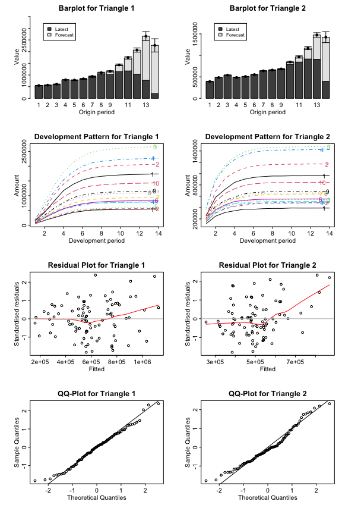

Summary and diagnostic plots from a `MultiChainLadder` object

### Other residual covariance estimation methods

Internally, the `MultiChainLadder` calls the `systemfit` function to fit the regression models period by period. When SUR models are specified, there are several ways to estimate the residual covariance matrix $\Sigma_k$. Available methods are `noDfCor`, `geomean`, `max`, and `Theil` with the default as `geomean`. The method `Theil` will produce unbiased covariance estimate, but the resulting estimate may not be positive semi-definite. This is also the estimator used by (Michael Merz and Wüthrich 2008b). However, this method does not work out of the box for the `liab` data, and is perhaps one of the reasons (Michael Merz and Wüthrich 2008b) used extrapolation to get the estimate for the last several periods.

Indeed, for most applications, we recommend the use of separate chain ladders for the tail periods to stabilize the estimation - there are few data points in the tail and running a multivariate model often produces extremely volatile estimates or even fails. To facilitate such an approach, the package offers the `MultiChainLadder2` function, which implements a split-and-join procedure: we split the input data into two parts, specify a multivariate model with rich structures on the first part (with enough data) to reflect the multivariate dependencies, apply separate univariate chain-ladders on the second part, and then join the two models together to produce the final predictions. The splitting is determined by the `last` argument, which specifies how many of the development periods in the tail go into the second part of the split. The type of the model structure to be specified for the first part of the split model in `MultiChainLadder2` is controlled by the `type` argument. It takes one of the following values: `MCL` - the multivariate chain-ladder with diagonal development matrix; `MCL+int` - the multivariate chain-ladder with additional intercepts; `GMCL-int` - the general multivariate chain-ladder without intercepts; and `GMCL` - the full general multivariate chain-ladder with intercepts and non-diagonal development matrix.

For example, the following fits the SUR method to the first part (the first 11 columns) using the unbiased residual covariance estimator in (Michael Merz and Wüthrich 2008b), and separate chain-ladders for the rest:

```r
require(systemfit)
W1 <- MultiChainLadder2(liab, mse.method = "Independence",
        control = systemfit.control(methodResidCov = "Theil"))
lapply(summary(W1)$report.summary, "[", 15, )
```

```
$`Summary Statistics for Triangle 1`
        Latest Dev.To.Date Ultimate    IBNR    S.E     CV
Total 11343397      0.6483 17497403 6154006 427041 0.0694

$`Summary Statistics for Triangle 2`
       Latest Dev.To.Date Ultimate    IBNR    S.E    CV
Total 8759806      0.8095 10821034 2061228 162785 0.079

$`Summary Statistics for Triangle 1+2`
        Latest Dev.To.Date Ultimate    IBNR    S.E     CV
Total 20103203      0.7099 28318437 8215234 505376 0.0615
```

Similarly, the iterative residual covariance estimator in (Michael Merz and Wüthrich 2008b) can also be used, in which we use the control parameter `maxiter` to determine the number of iterations:

```r
for (i in 1:5){
  W2 <- MultiChainLadder2(liab, mse.method = "Independence",
      control = systemfit.control(methodResidCov = "Theil", maxiter = i))
  print(format(summary(W2)@report.summary[[3]][15, 4:5],
          digits = 6, big.mark = ","))
}
```

```
           IBNR     S.E
Total 8,215,234 505,376
           IBNR     S.E
Total 8,215,357 505,443
           IBNR     S.E
Total 8,215,362 505,444
           IBNR     S.E
Total 8,215,362 505,444
           IBNR     S.E
Total 8,215,362 505,444
```

```r
lapply(summary(W2)$report.summary, "[", 15, )
```

```
$`Summary Statistics for Triangle 1`
        Latest Dev.To.Date Ultimate    IBNR    S.E     CV
Total 11343397      0.6483 17497526 6154129 427074 0.0694

$`Summary Statistics for Triangle 2`
       Latest Dev.To.Date Ultimate    IBNR    S.E    CV
Total 8759806      0.8095 10821039 2061233 162790 0.079

$`Summary Statistics for Triangle 1+2`
        Latest Dev.To.Date Ultimate    IBNR    S.E     CV
Total 20103203      0.7099 28318565 8215362 505444 0.0615
```

We see that the covariance estimate converges in three steps. These are very similar to the results in (Michael Merz and Wüthrich 2008b), the small difference being a result of the different approaches used in the last three periods.

Also note that in the above two examples, the argument `control` is not defined in the prototype of the `MultiChainLadder`. It is an argument that is passed to the `systemfit` function through the `...` mechanism. Users are encouraged to explore how other options available in `systemfit` can be applied.

### Model with intercepts

Consider the `auto` triangles from (Zhang 2010). It includes three automobile insurance triangles: personal auto paid, personal auto incurred, and commercial auto paid.

```r
str(auto)
```

```
List of 3
 $ PersonalAutoPaid    : num [1:10, 1:10] 101125 102541 114932 114452 115597 ...
 $ PersonalAutoIncurred: num [1:10, 1:10] 325423 323627 358410 405319 434065 ...
 $ CommercialAutoPaid  : num [1:10, 1:10] 19827 22331 22533 23128 25053 ...
```

It is a reasonable expectation that these triangles will be correlated. So we run a MCL model on them:

```r
f0 <- MultiChainLadder2(auto, type = "MCL")
# show correlation- the last three columns have zero correlation
# because separate chain-ladders are used
print(do.call(cbind, residCor(f0)), digits = 3)
```

```
       [,1]    [,2]  [,3]  [,4]    [,5]  [,6] [,7] [,8] [,9]
(1,2) 0.327 -0.0101 0.598 0.711  0.8565 0.928    0    0    0
(1,3) 0.870  0.9064 0.939 0.261 -0.0607 0.911    0    0    0
(2,3) 0.198 -0.3217 0.558 0.380  0.3586 0.931    0    0    0
```

We can improve the above model by including intercepts in the SUR fit as follows:

```r
f1 <- MultiChainLadder2(auto, type = "MCL+int")
```

**!The rest of this and the following section needs updating following changes to the Matrix package!**

The default summary computes the portfolio estimates as the sum of all the triangles. This is not desirable because the first two triangles are both from the personal auto line. We can overwrite this via the `portfolio` argument. For example, the following uses the two paid triangles as the portfolio estimate:

```r
lapply(summary(f1, portfolio = "1+3")@report.summary, "[", 11, )
```

[output not shown]

### Joint modelling of the paid and incurred losses

Although the model with intercepts proved to be an improvement over the MCL model, it still fails to account for the structural relationship between triangles. In particular, it produces divergent paid-to-incurred loss ratios for the personal auto line:

```r
ult <- summary(f1)$Ultimate
print(ult[, 1] /ult[, 2], 3)
```

[output not shown]

We illustrate this ignoring the commercial auto triangle. See the demo for a model that uses all three triangles. We also include the MCL model and the Munich chain-ladder as a comparison:

```r
da <- auto[1:2]
# MCL with diagonal development
M0 <- MultiChainLadder(da)
# non-diagonal development matrix with no intercepts
M1 <- MultiChainLadder2(da, type = "GMCL-int")
# Munich chain-ladder
M2 <- MunichChainLadder(da[[1]], da[[2]])
# compile results and compare projected paid to incured ratios
r1 <- lapply(list(M0, M1), function(x){
          ult <- summary(x)@Ultimate
          ult[, 1] / ult[, 2]
      })
names(r1) <- c("MCL", "GMCL")
r2 <- summary(M2)[[1]][, 6]
r2 <- c(r2, summary(M2)[[2]][2, 3])
print(do.call(cbind, c(r1, list(MuCl = r2))) * 100, digits = 4)
```

[output not shown]

## Clark’s methods

The ChainLadder package contains functionality to carry out the methods described in the paper[^3] by David Clark (Clark 2003). Using a longitudinal analysis approach, Clark assumes that losses develop according to a theoretical *growth curve*. The LDF method is a special case of this approach where the growth curve can be considered to be either a step function or piecewise linear. Clark envisions a growth curve as measuring the percent of ultimate loss that can be expected to have emerged as of each age of an origin period. The paper describes two methods that fit this model.

The LDF method assumes that the ultimate losses in each origin period are separate and unrelated. The goal of the method, therefore, is to estimate parameters for the ultimate losses and for the growth curve in order to maximize the likelihood of having observed the data in the triangle.

The CapeCod method assumes that the *apriori* expected ultimate losses in each origin year are the product of earned premium that year and a theoretical loss ratio. The CapeCod method, therefore, need estimate potentially far fewer parameters: for the growth function and for the theoretical loss ratio.

One of the side benefits of using maximum likelihood to estimate parameters is that its associated asymptotic theory provides uncertainty estimates for the parameters. Observing that the reserve estimates by origin year are functions of the estimated parameters, uncertainty estimates of these functional values are calculated according to the *Delta method*, which is essentially a linearisation of the problem based on a Taylor series expansion.

The two functional forms for growth curves considered in Clark’s paper are the log-logistic function (a.k.a., the inverse power curve) and the Weibull function, both being two-parameter functions. Clark uses the parameters $\omega$ and $\theta$ in his paper. Clark’s methods work on incremental losses. His likelihood function is based on the assumption that incremental losses follow an over-dispersed Poisson (ODP) process.

### Clark’s LDF method

Consider again the RAA triangle. Accepting all defaults, the Clark LDF Method would estimate total ultimate losses of 272,009 and a reserve (FutureValue) of 111,022, or almost twice the value based on the volume weighted average link ratios and loglinear fit in section 3.2.1 above.

```r
ClarkLDF(RAA)
```

```
 Origin CurrentValue    Ldf UltimateValue FutureValue StdError  CV%
   1981       18,834  1.216        22,906       4,072    2,792 68.6
   1982       16,704  1.251        20,899       4,195    2,833 67.5
   1983       23,466  1.297        30,441       6,975    4,050 58.1
   1984       27,067  1.360        36,823       9,756    5,147 52.8
   1985       26,180  1.451        37,996      11,816    5,858 49.6
   1986       15,852  1.591        25,226       9,374    4,877 52.0
   1987       12,314  1.829        22,528      10,214    5,206 51.0
   1988       13,112  2.305        30,221      17,109    7,568 44.2
   1989        5,395  3.596        19,399      14,004    7,506 53.6
   1990        2,063 12.394        25,569      23,506   17,227 73.3
  Total      160,987              272,009     111,022   36,102 32.5
```

Most of the difference is due to the heavy tail, 21.6%, implied by the inverse power curve fit. Clark recognizes that the log-logistic curve can take an unreasonably long length of time to flatten out. If according to the actuary’s experience most claims close as of, say, 20 years, the growth curve can be truncated accordingly by using the `maxage` argument:

```r
ClarkLDF(RAA, maxage = 20)
```

```
 Origin CurrentValue    Ldf UltimateValue FutureValue StdError  CV%
   1981       18,834  1.124        21,168       2,334    1,765 75.6
   1982       16,704  1.156        19,314       2,610    1,893 72.6
   1983       23,466  1.199        28,132       4,666    2,729 58.5
   1984       27,067  1.257        34,029       6,962    3,559 51.1
   1985       26,180  1.341        35,113       8,933    4,218 47.2
   1986       15,852  1.471        23,312       7,460    3,775 50.6
   1987       12,314  1.691        20,819       8,505    4,218 49.6
   1988       13,112  2.130        27,928      14,816    6,300 42.5
   1989        5,395  3.323        17,927      12,532    6,658 53.1
   1990        2,063 11.454        23,629      21,566   15,899 73.7
  Total      160,987              251,369      90,382   26,375 29.2
```

The Weibull growth curve tends to be faster developing than the log-logistic:

```r
ClarkLDF(RAA, G="weibull")
```

```
 Origin CurrentValue   Ldf UltimateValue FutureValue StdError   CV%
   1981       18,834 1.022        19,254         420      700 166.5
   1982       16,704 1.037        17,317         613      855 139.5
   1983       23,466 1.060        24,875       1,409    1,401  99.4
   1984       27,067 1.098        29,728       2,661    2,037  76.5
   1985       26,180 1.162        30,419       4,239    2,639  62.2
   1986       15,852 1.271        20,151       4,299    2,549  59.3
   1987       12,314 1.471        18,114       5,800    3,060  52.8
   1988       13,112 1.883        24,692      11,580    4,867  42.0
   1989        5,395 2.988        16,122      10,727    5,544  51.7
   1990        2,063 9.815        20,248      18,185   12,929  71.1
  Total      160,987             220,920      59,933   19,149  32.0
```

It is recommend to inspect the residuals to help assess the reasonableness of the model relative to the actual data.

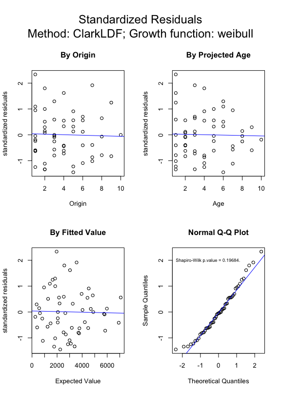

```r
plot(ClarkLDF(RAA, G="weibull"))
```

Although there is some evidence of heteroscedasticity with increasing ages and fitted values, the residuals otherwise appear randomly scattered around a horizontal line through the origin. The q-q plot shows evidence of a lack of fit in the tails, but the p-value of almost 0.2 can be considered too high to reject outright the assumption of normally distributed standardized residuals[^4].

### Clark’s Cape Cod method

The RAA data set, widely researched in the literature, has no premium associated with it traditionally. Let’s assume a constant earned premium of 40000 each year, and a Weibull growth function:

```r
ClarkCapeCod(RAA, Premium = 40000, G = "weibull")
```

```
 Origin CurrentValue Premium   ELR FutureGrowthFactor FutureValue UltimateValue
   1981       18,834  40,000 0.566             0.0192         436        19,270
   1982       16,704  40,000 0.566             0.0320         725        17,429
   1983       23,466  40,000 0.566             0.0525       1,189        24,655
   1984       27,067  40,000 0.566             0.0848       1,921        28,988
   1985       26,180  40,000 0.566             0.1345       3,047        29,227
   1986       15,852  40,000 0.566             0.2093       4,741        20,593
   1987       12,314  40,000 0.566             0.3181       7,206        19,520
   1988       13,112  40,000 0.566             0.4702      10,651        23,763
   1989        5,395  40,000 0.566             0.6699      15,176        20,571
   1990        2,063  40,000 0.566             0.9025      20,444        22,507
  Total      160,987 400,000                               65,536       226,523
 StdError   CV%
      692 158.6
      912 125.7
    1,188  99.9
    1,523  79.3
    1,917  62.9
    2,360  49.8
    2,845  39.5
    3,366  31.6
    3,924  25.9
    4,491  22.0
   12,713  19.4
```

The estimated expected loss ratio is 0.566. The total outstanding loss is about 10% higher than with the LDF method. The standard error, however, is lower, probably due to the fact that there are fewer parameters to estimate with the CapeCod method, resulting in less parameter risk.

A plot of this model shows similar residuals By Origin and Projected Age to those from the LDF method, a better spread By Fitted Value, and a slightly better q-q plot, particularly in the upper tail.

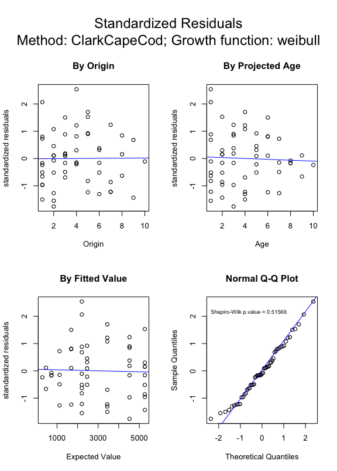

```r
plot(ClarkCapeCod(RAA, Premium = 40000, G = "weibull"))
```

## Generalised linear model methods

Recent years have also seen growing interest in using generalised linear models [GLM] for insurance loss reserving. The use of GLM in insurance loss reserving has many compelling aspects, e.g.,

- when over-dispersed Poisson model is used, it reproduces the estimates from chain-ladder;
- it provides a more coherent modelling framework than the Mack method;
- all the relevant established statistical theory can be directly applied to perform hypothesis testing and diagnostic checking;

The `glmReserve` function takes an insurance loss triangle, converts it to incremental losses internally if necessary, transforms it to the long format (see `as.data.frame`) and fits the resulting loss data with a generalised linear model where the mean structure includes both the accident year and the development lag effects. The function also provides both analytical and bootstrapping methods to compute the associated prediction errors. The bootstrapping approach also simulates the full predictive distribution, based on which the user can compute other uncertainty measures such as predictive intervals.

Only the Tweedie family of distributions are allowed, that is, the exponential family that admits a power variance function $V(\mu)=\mu^p$. The variance power $p$ is specified in the `var.power` argument, and controls the type of the distribution. When the Tweedie compound Poisson distribution $1 < p < 2$ is to be used, the user has the option to specify `var.power = NULL`, where the variance power $p$ will be estimated from the data using the `cplm` package (Zhang 2012).

For example, the following fits the over-dispersed Poisson model and spells out the estimated reserve information:

```r
# load data
data(GenIns)
GenIns <- GenIns / 1000
# fit Poisson GLM
(fit1 <- glmReserve(GenIns))
```

```
      Latest Dev.To.Date Ultimate  IBNR    S.E     CV
2       5339     0.98252     5434    95  110.1 1.1589
3       4909     0.91263     5379   470  216.0 0.4597
4       4588     0.86599     5298   710  260.9 0.3674
5       3873     0.79725     4858   985  303.6 0.3082
6       3692     0.72235     5111  1419  375.0 0.2643
7       3483     0.61527     5661  2178  495.4 0.2274
8       2864     0.42221     6784  3920  790.0 0.2015
9       1363     0.24162     5642  4279 1046.5 0.2446
10       344     0.06922     4970  4626 1980.1 0.4280
total  30457     0.61982    49138 18681 2945.7 0.1577
```

We can also extract the underlying GLM model by specifying `type = "model"` in the `summary` function:

```r
summary(fit1, type = "model")
```

```
Call:
glm(formula = value ~ factor(origin) + factor(dev), family = fam,
    data = ldaFit, offset = offset)

Coefficients:
                 Estimate Std. Error t value Pr(>|t|)
(Intercept)       5.59865    0.17292   32.38  < 2e-16 ***
factor(origin)2   0.33127    0.15354    2.16   0.0377 *
factor(origin)3   0.32112    0.15772    2.04   0.0492 *
factor(origin)4   0.30596    0.16074    1.90   0.0650 .
factor(origin)5   0.21932    0.16797    1.31   0.1999
factor(origin)6   0.27008    0.17076    1.58   0.1225
factor(origin)7   0.37221    0.17445    2.13   0.0398 *
factor(origin)8   0.55333    0.18653    2.97   0.0053 **
factor(origin)9   0.36893    0.23918    1.54   0.1317
factor(origin)10  0.24203    0.42756    0.57   0.5749
factor(dev)2      0.91253    0.14885    6.13  4.7e-07 ***
factor(dev)3      0.95883    0.15257    6.28  2.9e-07 ***
factor(dev)4      1.02600    0.15688    6.54  1.3e-07 ***
factor(dev)5      0.43528    0.18391    2.37   0.0234 *
factor(dev)6      0.08006    0.21477    0.37   0.7115
factor(dev)7     -0.00638    0.23829   -0.03   0.9788
factor(dev)8     -0.39445    0.31029   -1.27   0.2118
factor(dev)9      0.00938    0.32025    0.03   0.9768
factor(dev)10    -1.37991    0.89669   -1.54   0.1326
---
Signif. codes:  0 '***' 0.001 '**' 0.01 '*' 0.05 '.' 0.1 ' ' 1

(Dispersion parameter for Tweedie family taken to be 52.6)

    Null deviance: 10699  on 54  degrees of freedom
Residual deviance:  1903  on 36  degrees of freedom
AIC: NA

Number of Fisher Scoring iterations: 4
```

Similarly, we can fit the Gamma and a compound Poisson GLM reserving model by changing the `var.power` argument:

```r
# Gamma GLM
(fit2 <- glmReserve(GenIns, var.power = 2))
```

```
      Latest Dev.To.Date Ultimate  IBNR     S.E     CV
2       5339     0.98288     5432    93   45.17 0.4857
3       4909     0.91655     5356   447  160.56 0.3592
4       4588     0.88248     5199   611  177.62 0.2907
5       3873     0.79611     4865   992  254.47 0.2565
6       3692     0.71757     5145  1453  351.33 0.2418
7       3483     0.61440     5669  2186  526.29 0.2408
8       2864     0.43870     6529  3665  941.32 0.2568
9       1363     0.24854     5485  4122 1175.95 0.2853
10       344     0.07078     4860  4516 1667.39 0.3692
total  30457     0.62742    48543 18086 2702.71 0.1494
```

```r
# compound Poisson GLM (variance function estimated from the data):
# (fit3 <- glmReserve(GenIns, var.power = NULL))
```

By default, the formulaic approach is used to compute the prediction errors. We can also carry out bootstrapping simulations by specifying `mse.method = "bootstrap"` (note that this argument supports partial match):

```r
set.seed(11)
(fit5 <- glmReserve(GenIns, mse.method = "boot"))
```

```
      Latest Dev.To.Date Ultimate  IBNR    S.E     CV
2       5339     0.98252     5434    95  108.7 1.1440
3       4909     0.91263     5379   470  207.8 0.4421
4       4588     0.86599     5298   710  270.4 0.3809
5       3873     0.79725     4858   985  306.6 0.3112
6       3692     0.72235     5111  1419  387.6 0.2732
7       3483     0.61527     5661  2178  493.3 0.2265
8       2864     0.42221     6784  3920  813.1 0.2074
9       1363     0.24162     5642  4279 1077.3 0.2518
10       344     0.06922     4970  4626 1986.3 0.4294
total  30457     0.61982    49138 18681 2955.4 0.1582
```

When bootstrapping is used, the resulting object has three additional components - `sims.par`, `sims.reserve.mean`, and `sims.reserve.pred` that store the simulated parameters, mean values and predicted values of the reserves for each year, respectively.

```r
names(fit5)
```

```
[1] "call"              "summary"           "Triangle"
[4] "FullTriangle"      "model"             "sims.par"
[7] "sims.reserve.mean" "sims.reserve.pred"
```

We can thus compute the quantiles of the predictions based on the simulated samples in the `sims.reserve.pred` element as:

```r
pr <- as.data.frame(fit5$sims.reserve.pred)
qv <- c(0.025, 0.25, 0.5, 0.75, 0.975)
res.q <- t(apply(pr, 2, quantile, qv))
print(format(round(res.q), big.mark = ","), quote = FALSE)
```

```
   2.5%  25%   50%   75%   97.5%
2      0    40    91   175   375
3    125   339   463   612   941
4    290   551   720   910 1,330
5    507   797   991 1,195 1,686
6    812 1,194 1,424 1,691 2,305
7  1,345 1,873 2,161 2,536 3,258
8  2,595 3,427 3,951 4,517 5,742
9  2,462 3,555 4,222 4,988 6,879
10   809 3,394 4,505 5,904 9,236
```

The full predictive distribution of the simulated reserves for each year can be visualized easily:

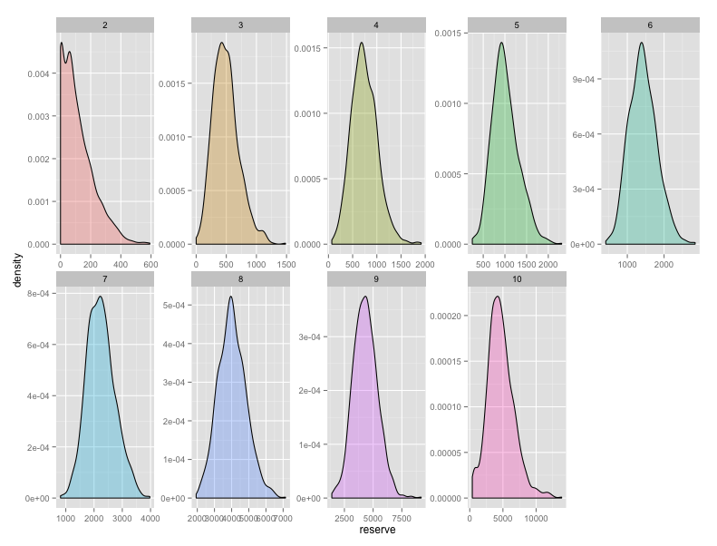

The predictive distribution of loss reserves for each year based on bootstrapping

```r
library(ggplot2)
prm <- reshape(pr, varying=list(names(pr)), v.names = "reserve",
               timevar = "year", direction="long")
gg <- ggplot(prm, aes(reserve))
gg <- gg + geom_density(aes(fill = year), alpha = 0.3) +
        facet_wrap(~year, nrow = 2, scales = "free")  +
         theme(legend.position = "none")
print(gg)
```

## Paid-incurred chain model

The Paid-incurred chain model was published by Merz and Wüthrich in 2010 (M. Merz and Wüthrich 2010). It combines claims payments and incurred losses information in a a mathematically rigorous and consistent way to get a unified ultimate loss prediction.

### Model assumptions

The model assumptions for the Log-Normal PIC Model are the following:

- Conditionally, given $\Theta = (\Phi_0,...,\Phi_I, \Psi_0,...,\Psi_{I-1},\sigma_0,...,\sigma_{I-1},\tau_0,...,\tau_{I-1}$ we have
  - the random vector $(\xi_{0,0},...,\xi_{I,I}, \zeta_{0,0},...,\zeta_{I,I-1})$ has multivariate Gaussian distribution with uncorrelated components given by $$
    $$\begin{equation*}
    \xi_{i,j} \sim N(\Phi_j,\sigma^2_j),
    \end{equation*}$$
    $$\begin{equation*}
    \zeta_{k,l} \sim N(\Psi_l,\tau^2_l);
    \end{equation*}$$
  - cumulative payments are given by the recursion
    $$\begin{equation*}
    P_{i,j} = P_{i,j-1} \exp(\xi_{i,j}),
    \end{equation*}$$
    $$ with initial value $P_{i,0} = \exp (\xi_{i,0})$;
  - incurred losses $I_{i,j}$ are given by the backwards recursion
    $$\begin{equation*}
    I_{i,j-1} = I_{i,j} \exp(-\zeta_{i,j-1}),
    \end{equation*}$$
    with initial value $I_{i,I}=P_{i,I}$.
- The components of $\Theta$ are independent and $\sigma_j,\tau_j > 0$ for all j.

### Parameter estimation

Parameters $\Theta$ in the model are in general not known and need to be estimated from observations. They are estimated in a Bayesian framework. In the Bayesian PIC model they assume that the previous assumptions hold true with deterministic $\sigma_0,...,\sigma_J$ and $\tau_0,...,\tau_{J-1}$ and

$$\begin{equation*}
\Phi_m \sim N(\phi_m,s^2_m),
\end{equation*}$$

$$\begin{equation*}
\Psi_n \sim N(\psi_n,t^2_n).
\end{equation*}$$

This is not a full Bayesian approach but has the advantage to give analytical expressions for the posterior distributions and the prediction uncertainty.

The Paid-incurred Chain model is implemented in the `ChainLadder` package via the function `PaidIncurredChain`. As an example we apply the function to the USAA paid and incurred triangles:

```r
PIC <- PaidIncurredChain(USAApaid, USAAincurred)
PIC
```

```
$Ult.Loss.Origin
         [,1]
 [1,]  983113
 [2,] 1078697
 [3,] 1145761
 [4,] 1245171
 [5,] 1371964
 [6,] 1433857
 [7,] 1415964
 [8,] 1410065
 [9,] 1320415

$Ult.Loss
[1] 11405008

$Res.Origin
          [,1]
 [1,]    965.3
 [2,]   3159.6
 [3,]   7386.4
 [4,]  18521.4
 [5,]  47232.4
 [6,] 113727.4
 [7,] 230663.7
 [8,] 443903.3
 [9,] 778393.5

$Res.Tot
[1] 1643953

$s.e.
[1] 113940
```

We can access the reserves by origin year via

```r
PIC$Res.Origin
```

```
          [,1]
 [1,]    965.3
 [2,]   3159.6
 [3,]   7386.4
 [4,]  18521.4
 [5,]  47232.4
 [6,] 113727.4
 [7,] 230663.7
 [8,] 443903.3
 [9,] 778393.5
```

and the total reserve via

```r
PIC$Res.Tot
```

```
[1] 1643953
```

`s.e.` is the square root of mean square error of prediction for the total ultimate loss.

It’s important to notice that the model is implemented in the special case of non-informative priors for $\Phi_m$ and $\Psi_n$; this means that we let $s^2_m \to \infty$ and $t^2_n \to \infty$.

## One year claims development result

The stochastic claims reserving methods considered above predict the lower (unknown) triangle and assess the uncertainty of this prediction. For instance, Mack’s uncertainty formula quantifies the total prediction uncertainty of the chain-ladder predictor over the entire run-off of the outstanding claims. Modern solvency considerations, such as Solvency II, require a second view of claims reserving uncertainty. This second view is a short-term view because it requires assessments of the one-year changes of the claims predictions when one updates the available information at the end of each accounting year. At time $t\ge n$ we have information

$$\begin{equation*}
{\cal D}_{t}
= \left\{C_{i,k};~{i+k \le t+1} \right\}.
\end{equation*}$$

This motivates the following sequence of predictors for the ultimate claim $C_{i,K}$ at times $t\ge n$

$$\begin{equation*}
\widehat{C}^{(t)}_{i,K}= \mathbb{E}[C_{i,K}|{\cal D}_t].
\end{equation*}$$

The one year claims development results (CDR), see Merz-Wüthrich , consider the changes in these one year updates, that is,

$$\begin{equation*}
{\rm CDR}_{i,t+1}
=\widehat{C}^{(t)}_{i,K}-\widehat{C}^{(t+1)}_{i,K}.
\end{equation*}$$

The tower property of conditional expectation implies that the CDRs are on average 0, that is, $\mathbb{E}[{\rm CDR}_{i,t+1}|{\cal D}_t]=0$ and the Merz-Wüthrich formula (Michael Merz and Wüthrich 2008a), (Michael Merz and Wüthrich 2014) assesses the uncertainty of these predictions measured by the following conditional mean square error of prediction (MSEP)

$$\begin{equation*}
{\rm msep}_{{\rm CDR}_{i,t+1}|{\cal D}_t}(0)
= \mathbb{E} \left[\left.\left({\rm CDR}_{i,t+1}-0\right)^2
\right|{\cal D}_t \right].
\end{equation*}$$

The major difficulty in the evaluation of the conditional MSEP is the quantification of parameter estimation uncertainty.

### CDR functions

The one year claims development result (CDR) can be estimate via the generic `CDR` function for objects of `MackChainLadder` and `BootChainLadder`.

Further, the `tweedieReserve` function offers also the option to estimate the one year CDR, by setting the argument `rereserving=TRUE`.

For example, to reproduce the results of (Michael Merz and Wüthrich 2014) use:

```r
M <- MackChainLadder(MW2014, est.sigma="Mack")
cdrM <- CDR(M)
round(cdrM, 1)
```

```
         IBNR CDR(1)S.E. Mack.S.E.
1         0.0        0.0       0.0
2         1.0        0.4       0.4
3        10.1        2.5       2.6
4        21.2       16.7      16.9
5       117.7      156.4     157.3
6       223.3      137.7     207.2
7       361.8      171.2     261.9
8       469.4       70.3     292.3
9       653.5      271.6     390.6
10     1008.8      310.1     502.1
11     1011.9      103.4     486.1
12     1406.7      632.6     806.9
13     1492.9      315.0     793.9
14     1917.6      406.1     891.7
15     2458.2      285.2     916.5
16     3384.3      668.2    1106.1
17     9596.6      733.2    1295.7
Total 24134.9     1842.9    3233.7
```

To review the full claims development picture set the argument `dev="all"`:

```r
cdrAll <- CDR(M,dev="all")
round(cdrAll, 1)
```

```
         IBNR CDR(1)S.E. CDR(2)S.E. CDR(3)S.E. CDR(4)S.E. CDR(5)S.E. CDR(6)S.E.
1         0.0        0.0        0.0        0.0        0.0        0.0        0.0
2         1.0        0.4        0.0        0.0        0.0        0.0        0.0
3        10.1        2.5        0.4        0.0        0.0        0.0        0.0
4        21.2       16.7        2.4        0.3        0.0        0.0        0.0
5       117.7      156.4       16.4        2.4        0.3        0.0        0.0
6       223.3      137.7      154.0       16.1        2.3        0.3        0.0
7       361.8      171.2      131.0      148.0       15.5        2.2        0.3
8       469.4       70.3      185.0      141.8      160.9       16.8        2.4
9       653.5      271.6       61.8      178.0      136.9      155.7       16.3
10     1008.8      310.1      274.6       59.0      180.4      138.6      158.1
11     1011.9      103.4      293.0      260.0       53.0      170.9      131.4
12     1406.7      632.6      102.3      302.2      268.7       52.8      176.6
13     1492.9      315.0      572.1       86.6      273.0      242.8       45.4
14     1917.6      406.1      313.3      573.0       84.4      273.1      243.1
```

[output cut: 42 more lines]

See the help files to `CDR` and `tweedieReserve` for more details.

## Model Validation with tweedieReserve

Model validation is one of the key activities when an insurance company goes through the Internal Model Approval Process with the regulator. This section gives some examples how the arguments of the `tweedieReserve` function can be used to validate a stochastic reserving model. The argument `design.type` allows us to test different regression structures. The classic over-dispersed Poisson (ODP) model uses the following structure:

$$\begin{equation*}
Y \backsim \mathtt{as.factor}(OY) + \mathtt{as.factor}(DY),
\end{equation*}$$

(i.e. `design.type=c(1,1,0)`). This allows, together with the log link, to achieve the same results of the (volume weighted) chain-ladder model, thus the same model implied assumptions. A common model shortcoming is when the residuals plotted by calendar period start to show a pattern, which chain-ladder isn’t capable to model. In order to overcome this, the user could be then interested to change the regression structure in order to try to strip out these patterns (Gigante and Sigalotti 2005). For example, a regression structure like:

$$\begin{equation*}
Y \backsim \mathtt{as.factor}(DY) + \mathtt{as.factor}(CY),
\end{equation*}$$

i.e. `design.type=c(0,1,1)` could be considered instead. This approach returns the same results of the arithmetic separation method, modelling explicitly inflation parameters between consequent calendar periods. Another interesting assumption is the assumed underlying distribution. The ODP model assumes the following:

$$\begin{equation*}
P_{i,j} \backsim ODP(m_{i,j},\phi \cdot m_{i,j}),
\end{equation*}$$

which is a particular case of a Tweedie distribution, with `p` parameter equals to 1. Generally speaking, for any random variable Y that obeys a Tweedie distribution, the variance $\mathbb{V}[Y]$ relates to the mean $\mathbb{E}[Y]$ by the following law:

$$\begin{equation*}
\mathbb{V}[Y] = a \cdot \mathbb{E}[Y]^p,
\end{equation*}$$

where `a` and `p` are positive constants. The user is able to test different `p` values through the `var.power` function argument. Besides, in order to validate the Tweedie’s `p` parameter, it could be interesting to plot the likelihood profile at defined `p` values (through the `p.check` argument) for a given a dataset and a regression structure. This could be achieved setting the `p.optim=TRUE` argument.

```r
 p_profile <- tweedieReserve(MW2008, p.optim=TRUE,
   p.check=c(0,1.1,1.2,1.3,1.4,1.5,2,3),
   design.type=c(0,1,1),
   rereserving=FALSE,
   bootstrap=0,
   progressBar=FALSE)
# 0 1.1 1.2 1.3 1.4 1.5 2 3
# ........Done.
# MLE of p is between 0 and 1, which is impossible.
# Instead, the MLE of p has been set to NA .
# Please check your data and the call to tweedie.profile().
# Error in if ((xi.max == xi.vec[1]) | (xi.max == xi.vec[length(xi.vec)])) { :
# missing value where TRUE/FALSE needed
```

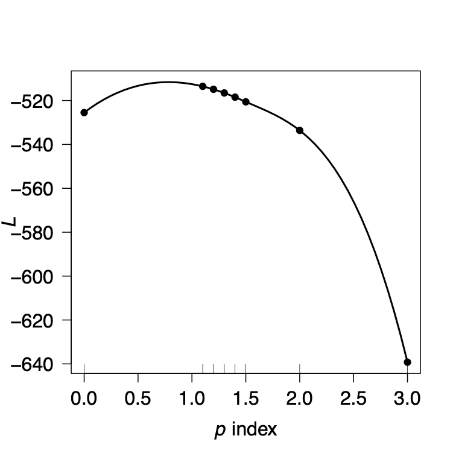

This example shows that the MLE of p seems to be between 0 and 1, which is not possible as Tweedie models aren’t defined for 0 < p < 1, thus the Error message. But, despite this, we can conclude that overall a value `p=1` could be reasonable for this dataset and the chosen regression function, as it seems to be near the MLE. Other sensitivities could be run on:

- Bootstrap type (parametric / semi-parametric), via the `bootstrap` argument
- Bias adjustment (if using semi-parametric bootstrap), via the `boot.adj` argument

Please refer to `help(tweedieReserve)` for additional information.

## Further resources

For a full Bayesian approach to claims reserving in R with Stan using the brms package see [‘Hierarchical Compartmental Reserving Models’](https://compartmentalmodels.gitlab.io/researchpaper/index.html) (Gesmann and Morris 2020).

Other useful documents and resources to get started with R in the context of actuarial work:

- Introduction to R for Actuaries (De Silva 2006).
- Computational Actuarial Science with R (Charpentier 2014)
- Modern Actuarial Risk Theory – Using R (Kaas et al. 2001)
- An Actuarial Toolkit (Maynard et al. 2006)
- Insurance Data Science conference: https://insurancedatascience.org

### Other insurance related R packages

Below is a list of further R packages in the context of insurance. The list is by no-means complete, and the CRAN Task Views [‘Empirical Finance’](https://CRAN.R-project.org/view=Finance) and [‘Probability Distributions’](https://CRAN.R-project.org/view=Distributions) will provide links to additional resources.

- cplm: Likelihood-based and Bayesian methods for fitting Tweedie compound Poisson linear models (Zhang 2012).
- DCL: Claims Reserving under the Double Chain-Ladder Model. Statistical modelling and forecasting in claims reserving in non-life insurance under the Double Chain-Ladder framework by (Miranda, Nielsen, and Verrall 2012).
- actuar: Loss distributions modelling, risk theory (including ruin theory), simulation of compound hierarchical models and credibility theory (Dutang, Goulet, and Pigeon 2008).
- fitdistrplus: Help to fit of a parametric distribution to non-censored or censored data (Delignette-Muller et al. 2010).
- mondate: R package to keep track of dates in terms of months (Murphy 2021).
- lifecontingencies: Package to perform actuarial evaluation of life contingencies (Spedicato 2022).
- raw: R Actuarial Workshops, several sets of publicly available data of interest to non-life actuaries (Fannin 2021)
- SPLICE: Synthetic Paid Loss and Incurred Cost Experience (SPLICE) Simulator (Avanzi, Taylor, and Wang 2021)
- SynthETIC: Synthetic Experience Tracking Insurance Claims (Avanzi et al. 2021)
- NetSimR: Actuarial Functions for Non-Life Insurance Modelling (Parizas 2019)

No longer on CRAN:

- lossDev: A Bayesian time series loss development model. Features include skewed-t distribution with time-varying scale parameter, Reversible Jump MCMC for determining the functional form of the consumption path, and a structural break in this path (Laws and Schmid 2011).
- favir: Formatted Actuarial Vignettes in R. FAViR lowers the learning curve of the R environment. It is a series of peer-reviewed Sweave papers that use a consistent style (Escoto 2011).
- MRMR: Multivariate Regression Models for Reserving (Fannin 2013).

# References

Avanzi, Benjamin, Greg Taylor, and Melantha Wang. 2021. *SPLICE: Synthetic Paid Loss and Incurred Cost Experience (SPLICE) Simulator*. https://CRAN.R-project.org/package=SPLICE.

Avanzi, Benjamin, Greg Taylor, Melantha Wang, and Bernard Wong. 2021. “SynthETIC: An Individual Insurance Claim Simulator with Feature Control.” *Insurance: Mathematics and Economics* 100 (September): 296–308. https://doi.org/10.1016/j.insmatheco.2021.06.004.

Buchwalder, M., H. Bühlmann, M. Merz, and M. V Wüthrich. 2006. “The Mean Square Error of Prediction in the Chain Ladder Reserving Method (Mack and Murphy Revisited).” *North American Actuarial Journal* 36: 521–42.

Charpentier, Arthur, ed. 2014. *Computational Actuarial Science with R*. Chapman; Hall/CRC.

Clark, David R. 2003. *LDF Curve-Fitting and Stochastic Reserving: A Maximum Likelihood Approach*. Casualty Actuarial Society; https://www.casact.org/sites/default/files/database/forum_03fforum_03ff041.pdf.

De Silva, Nigel. 2006. “An Introduction to r: Examples for Actuaries.” Actuarial Toolkit Working Party; http://toolkit.pbworks.com/RToolkit.

Delignette-Muller, Marie Laure, Regis Pouillot, Jean-Baptiste Denis, and Christophe Dutang. 2010. *Fitdistrplus: Help to Fit of a Parametric Distribution to Non-Censored or Censored Data*.

Dutang, C, V. Goulet, and M. Pigeon. 2008. “Actuar: An R Package for Actuarial Science.” *Journal of Statistical Software* 25 (7).

England, Peter, and Richard Verrall. 2002. “Stochastic Claims Reserving in General Insurance.” *British Actuarial Journal* 8: 443–544.

Escoto, Benedict. 2011. *Favir: Formatted Actuarial Vignettes in r*. 0.5–1st ed. https://github.com/cran/favir.

Fannin, Brian A. 2013. *MRMR: Multivariate Regression Models for Reserving*. https://CRAN.R-project.org/package=MRMR.

———. 2021. *Raw: R Actuarial Workshops*. https://CRAN.R-project.org/package=raw.

Gesmann, Markus. 2014. “Claims Reserving and IBNR.” In *Computational Actuarial Science with R*, 545–84. Chapman; Hall/CRC.

Gesmann, Markus, and Jake Morris. 2020. *Hierarchical Compartmental Reserving Models*. Casualty Actuarial Society; https://www.casact.org/sites/default/files/2021-02/compartmental-reserving-models-gesmannmorris0820.pdf.

Gigante, and Sigalotti. 2005. “Model Risk in Claims Reserving with GLM.” *Giornale Dell IIA* LXVIII: 55–87.

Gravelsons, Brian, Matthew Ball, Dan Beard, Robert Brooks, Naomi Couchman, Brian Gravelsons, Charlie Kefford, et al. 2009. “B12: UK Asbestos Working Party Update 2009.” https://www.actuaries.org.uk/system/files/documents/pdf/b12asbestoswp.pdf.

Henningsen, Arne, and Jeff D. Hamann. 2007. “Systemfit: A Package for Estimating Systems of Simultaneous Equations in r.” *Journal of Statistical Software* 23 (4): 1–40. https://doi.org/10.18637/jss.v023.i04.

Kaas, R., M. Goovaerts, J. Dhaene, and M. Denuit. 2001. *Modern Actuarial Risk Theory*. Dordrecht: Kluwer Academic Publishers.

Laws, Christopher W., and Frank A. Schmid. 2011. *lossDev: Robust Loss Development Using MCMC*. https://lossdev.r-forge.r-project.org.

Lyons, Graham, Will Forster, Paul Kedney, Ryan Warren, and Helen Wilkinson. 2002. *Claims Reserving Working Party Paper*. Institute of Actuaries.

Mack, Thomas. 1993. “Distribution-Free Calculation of the Standard Error of Chain Ladder Reserve Estimates.” *ASTIN Bulletin* 23: 213–25.

———. 1999. “The Standard Error of Chain Ladder Reserve Estimates: Recursive Calculation and Inclusion of a Tail Factor.” *Astin Bulletin* Vol. 29 (2): 361–266.

Maynard, Trevor, Nigel De Silva, Richard Holloway, Markus Gesmann, Sie Lau, and John Harnett. 2006. “An Actuarial Toolkit. Introducing The Toolkit Manifesto.” https://www.actuaries.org.uk/system/files/documents/pdf/actuarial-toolkit.pdf.

Merz, Michael, and Mario V. Wüthrich. 2008a. “Modelling the Claims Development Result for Solvency Purposes.” *CAS E-Forum* Fall: 542–68.

———. 2008b. “Prediction Error of the Multivariate Chain Ladder Reserving Method.” *North American Actuarial Journal* 12: 175–97.

———. 2014. “Laims Run-Off Uncertainty: The Full Picture.” *SSRN Manuscript* 2524352.

Merz, M., and M. Wüthrich. 2010. “Paid-Incurred Chain Claims Reserving Method.” *Insurance: Mathematics and Economics* 46(3): 568–79.

Michaels, Darren. 2002. “APH: How the Love Carnal and Silicone Implants Nearly Destroyed Lloyd’s (Slides).” Institute of Actuaries: https://www.actuaries.org.uk/system/files/documents/pdf/aph-how-love-canal-and-silicone-breasts.pdf.

Miranda, María Dolores Martínez, Jens Perch Nielsen, and Richard Verrall. 2012. “Double Chain Ladder.” *ASTIN Bulletin* 42 (1): 59–76. https://doi.org/10.2143/AST.42.1.2160712.

Murphy, Daniel. 1994. “Unbiased Loss Development Factors.” *PCAS* 81: 154–222.

———. 2021. *Mondate: Keep Track of Dates in Terms of Months*. https://CRAN.R-project.org/package=mondate.

Orr, James. 2012. *GIROC Reserving Research Workstream*. Institute of Actuaries.

Parizas, Yiannis. 2019. “Escaping the Triangle.” *The Actuary Magazine* June.

Pröhl, Carsten, and Klaus D. Schmidt. 2005. “Multivariate Chain-Ladder.” *Dresdner Schriften Zur Versicherungsmathematik*.

Quarg, Gerhard, and Thomas Mack. 2004. “Munich Chain Ladder.” Munich Re Group.

R Development Core Team. 2022a. *R Data Import/Export*. R Foundation for Statistical Computing; https://cran.r-project.org/doc/manuals/R-data.pdf.

———. 2022b. *R Installation and Administration*. R Foundation for Statistical Computing; https://cran.r-project.org/doc/manuals/R-admin.pdf.

Schmidt, Klaus D. 2017. “A Bibliography on Loss Reserving.” https://tu-dresden.de/mn/math/stochastik/ressourcen/dateien/schmidt/dsvm/reserve.pdf.

Spedicato, Giorgio Alfredo. 2022. *Introduction to Lifecontingencies Package*. 1.3.8 ed. StatisticalAdvisor Inc; https://CRAN.R-project.org/package=lifecontingencies/.

Zehnwirth, Ben, and Glen Barnett. 2000. “Best Estimates for Reserves.” *Proceedings of the CAS* LXXXVII (167).

Zhang, Yanwei. 2010. “A General Multivariate Chain Ladder Model.” *Insurance: Mathematics and Economics* 46: 588–99.

———. 2012. “Likelihood-Based and Bayesian Methods for Tweedie Compound Poisson Linear Mixed Models.” *Statistics and Computing*.

Zhang, Yanwei, Vanja Dukic, and James Guszcza. 2012. “A Bayesian Nonlinear Model for Forecasting Insurance Loss Payments.” *Journal of the Royal Statistical Society, Series A* 175: 637–56.

[^1]: See the `RODBC` and `DBI` packages
[^2]: Please ensure that your CSV-file is free from formatting, e.g. characters to separate units of thousands, as those columns will be read as characters or factors rather than numerical values.
[^3]: This paper is on the CAS Exam 6 syllabus
[^4]: As an exercise, the reader can confirm that the normal distribution assumption is rejected at the 5% level with the log-logistic curve